# Exploratory Data Analysis of Prosper Loan Data

Tania Moulik

February 27, 2018

### Introduction

In this report, I am analysing the Prosper Loan Data, using a number of different visualizations which can be categorized as univariate, bivariate and multivariate. A glimpse of the data shows that there are 81 varaibles and 113937 observations. For the sake of submission, I don’t print all the variables. I explain the variales I chose, as I explain each section. The variables pertain to the actual loan, and variables which can affect the credit score of a person which in turn influences the APR of the loan. First, I read the variables description in the provided file. Based on the available data, some of the broad questions I hope to address in this analysis are : a) How does the BorrowerAPR depend on Credit Score and other variables. b) What kinds of loans are there, and what leads to a loan being defaulted vs. being paid off? c) Which variables most influence the credit score?

Other questions that arise, while I visualize the data are mentioned in the separate chunks. I have combined univariate, bivariate and multivariate plots in the chunks because my focus was in understanding a variable well enough before investigating another which required a combination of plots.

##### Read Data File and first Look at the data.

First,I load the data and get the variable names, and take a first look by summarising the data.

The data set has 81 variables with 113937 observations for each. I then print out the column names and use glimpse to view the data.

I just print some of the variables here. (Note : The variables which I choose are talked about later. I am not making a selection here.I am showing the steps that I took, as I did the analysis as required in the project)

For the first look, I print out all column names and a summary of the data. But for the sake of submission, I am printing just a few variables as output.

```
## [1] "CreditGrade"             "Term"
## [3] "LoanStatus"              "ClosedDate"
## [5] "BorrowerAPR"             "BorrowerRate"
## [7] "LenderYield"             "EstimatedEffectiveYield"
## [9] "EstimatedLoss"
```

```
##   CreditGrade         Term                       LoanStatus
##         :84984   Min.   :12.00   Current              :56576
##  C      : 5649   1st Qu.:36.00   Completed            :38074
##  D      : 5153   Median :36.00   Chargedoff           :11992
##  B      : 4389   Mean   :40.83   Defaulted            : 5018
##  AA     : 3509   3rd Qu.:36.00   Past Due (1-15 days) :  806
##  HR     : 3508   Max.   :60.00   Past Due (31-60 days):  363
##  (Other): 6745                   (Other)              : 1108
##                ClosedDate     BorrowerAPR       BorrowerRate
##                     :58848   Min.   :0.00653   Min.   :0.0000
##  2014-03-04 00:00:00:  105   1st Qu.:0.15629   1st Qu.:0.1340
##  2014-02-19 00:00:00:  100   Median :0.20976   Median :0.1840
##  2014-02-11 00:00:00:   92   Mean   :0.21883   Mean   :0.1928
##  2012-10-30 00:00:00:   81   3rd Qu.:0.28381   3rd Qu.:0.2500
##  2013-02-26 00:00:00:   78   Max.   :0.51229   Max.   :0.4975
##  (Other)            :54633   NA's   :25
##   LenderYield      EstimatedEffectiveYield EstimatedLoss
##  Min.   :-0.0100   Min.   :-0.183          Min.   :0.005
##  1st Qu.: 0.1242   1st Qu.: 0.116          1st Qu.:0.042
##  Median : 0.1730   Median : 0.162          Median :0.072
##  Mean   : 0.1827   Mean   : 0.169          Mean   :0.080
##  3rd Qu.: 0.2400   3rd Qu.: 0.224          3rd Qu.:0.112
##  Max.   : 0.4925   Max.   : 0.320          Max.   :0.366
##                    NA's   :29084           NA's   :29084
```

The summary is very useful, because one can immediately get an idea of the type of variables and some of the important statistics such as mean, median and their quartiles. For categorical variables, it prints out the levels.

##### Missing Data

I am interested to see NA counts for the variables and count columns which have too many Null Values, as for visualization purposes I would like to look at variables which have enough statistics and can convey some details about the data. However, I am not choosing variables just because they have a low NA count. That choice is based on the questions I seek to answer. Still, I find it good to get an overall view of which variables have a lot of missing data.

Some of the varables in no particular preference or order, with large number of NA’s are

OpenCreditLines 7604  
PublicRecordsLast12Months 7604  
RevolvingCreditBalance 7604  
BankcardUtilization 7604  
AmountDelinquent 7622  
EmploymentStatusDuration 7625  
DebtToIncomeRatio 8554  
EstimatedEffectiveYield 29084  
EstimatedLoss 29084  
EstimatedReturn 29084

while those with 0 or small NA count’s are

IncomeVerifiable,StatedMonthlyIncome,LoanCurrentDaysDelinquent, LoanMonthsSinceOrigination,LoanNumber,LoanOriginalAmount,LoanOriginationDate and so on.

This is expected, as everyone has a loan, but some may be good lendees and not have Publicrecords, or have delinquent accounts. So for those people, this information will be unavailable.

### Variable Choice

Some variables that are very obvious choices for the study, based on the overall questions I posed earlier are the following:

- BorrowerAPR
- LoanStatus
- CreditScore
- CreditRange
- LoanCreationYear (Transformed from LoanOriginationDate)
- LoanCurrentDaysDelinquent

Some other variables are more difficult to choose at the first step of the analysis, and I chose them based on further studies. I list the variables I explored here, though the reasons for their choice are discussed later.

- EmploymentStatus
- CurrentCreditLines
- OpenCreditLines
- AmountDelinquent
- CurrentDelinquencies
- PublicRecordsLast12Months
- AvailableBankcardCredit
- TotalTrades
- TradesNeverDelinquent..percentage.
- DebtToIncomeRatio
- IncomeRange
- InquiriesLast6Months
- OpenRevolvingMonthlyPayment

#### BorrowerAPR Study

Firstly, I looked at the BorrowerAPR and wanted to see if the BorrowerAPR varies with Year. So for this I needed to extract the year. But my dilemma was which Date to use. There were a number of Date variables.

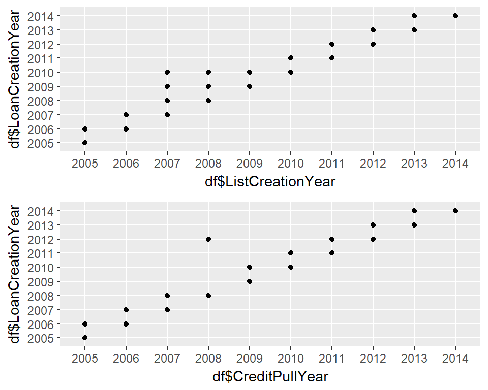

```r
df$ListCreationYear <- format(as.Date(df$ListingCreationDate),"%Y")
df$LoanCreationYear <- format(as.Date(df$LoanOriginationDate),"%Y")
df$CreditPullYear <- format(as.Date(df$DateCreditPulled),"%Y")
df$FirstRecordedCreditYear <- format(as.Date(df$FirstRecordedCreditLine),"%Y")

p1<- qplot(df$ListCreationYear,df$LoanCreationYear)
p2 <- qplot(df$CreditPullYear,df$LoanCreationYear)
grid.arrange(p1,p2,nrow=2)
```

#### New Variables :

Note that in 2007 and 2008 had there were some delays in allotting loans or perhaps that year had the highest amount of listings. So, Lets take a look at how many loans were approved for the different years

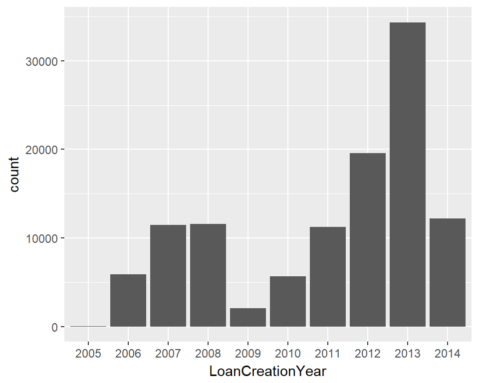

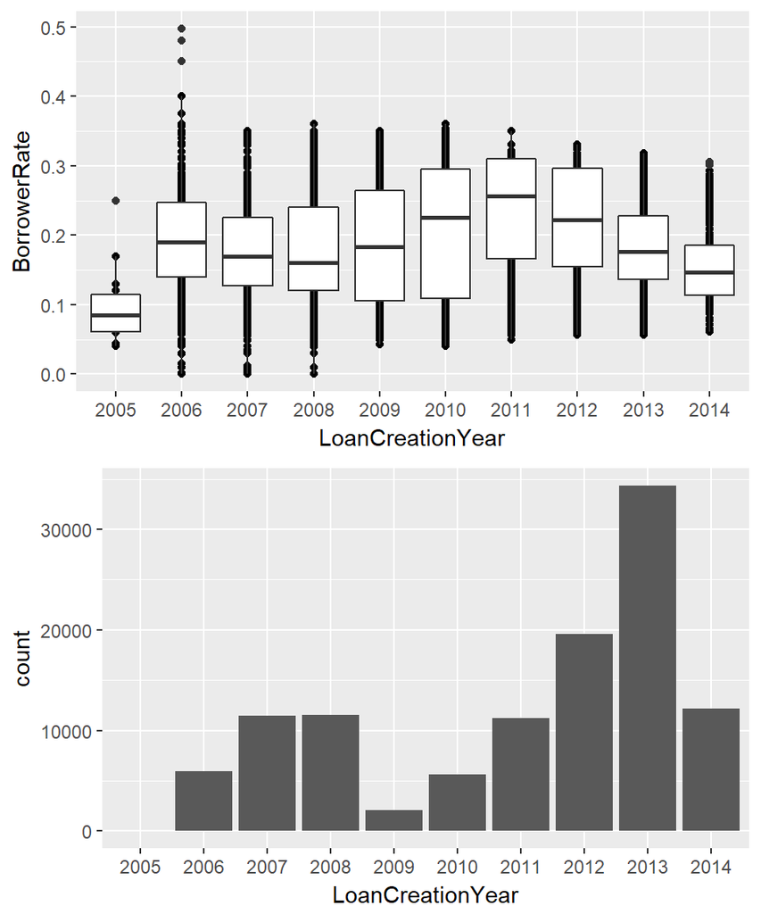

#### APR Trends

As can be seen in the boxplot there was a rising trend in APR between 2007 - 2011, and then it fell in 2012 and the trend continued until 2014. I would have expected the count (Number of applicants and hence Loan approvals) to be highest in 2014, but it could be that this data is not complete for 2014. So, it is not clear what caused the dip in counts in 2009 yet.

I could have extracted the month, but a quick and dirty sorting followed by tail, shows me that 2014 data ends in March, while 2013 data is complete.

```r
tail(sort(unique(df[df$LoanCreationYear=="2013","LoanOriginationDate"])))
```

```
## [1] 2013-12-23 00:00:00 2013-12-24 00:00:00 2013-12-26 00:00:00
## [4] 2013-12-27 00:00:00 2013-12-30 00:00:00 2013-12-31 00:00:00
## 1873 Levels: 2005-11-15 00:00:00 2005-11-18 00:00:00 ... 2014-03-12 00:00:00
```

```r
tail(sort(unique(df[df$LoanCreationYear=="2014","LoanOriginationDate"])))
```

```
## [1] 2014-03-05 00:00:00 2014-03-06 00:00:00 2014-03-07 00:00:00
## [4] 2014-03-10 00:00:00 2014-03-11 00:00:00 2014-03-12 00:00:00
## 1873 Levels: 2005-11-15 00:00:00 2005-11-18 00:00:00 ... 2014-03-12 00:00:00
```

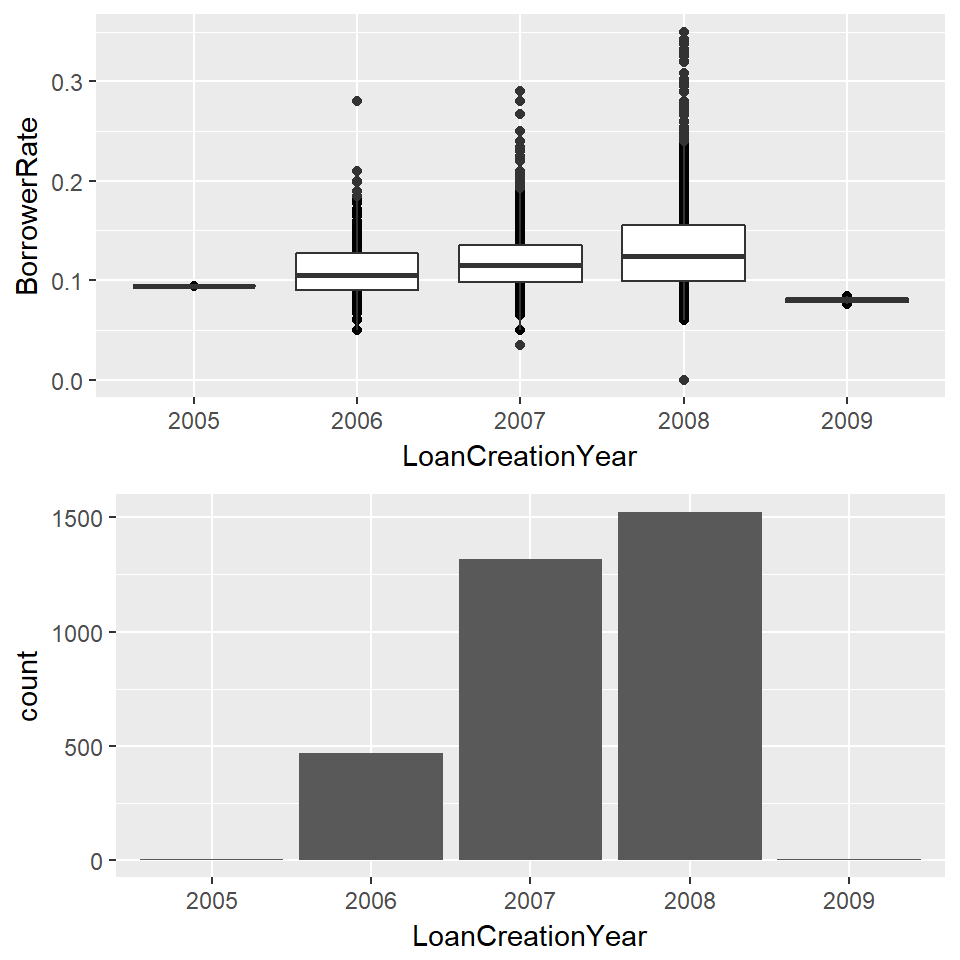

The above plots reveal something unexpected about the CreditGrade. It looks like only in 2006, 2007, 2008 there were users with CreditGrade A who were approved. That is unexpected. Why?

Lets look at this plot for the different Credit Grades separately.

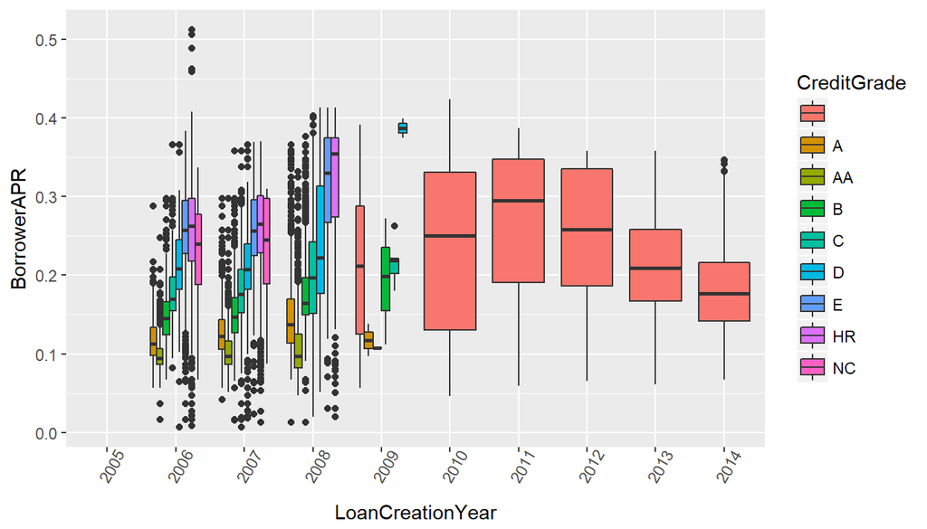

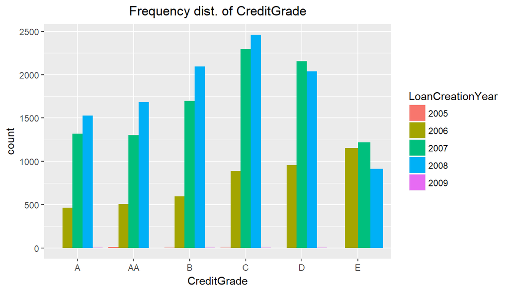

Lets now plot the loanStatus for data which have the credit Grades, ie. prior to year 2010.

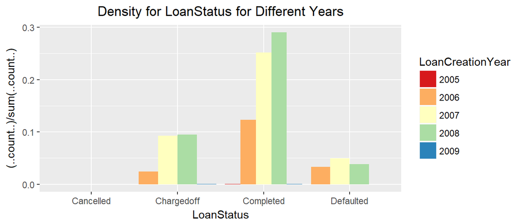

The following references gave another method - https://github.com/tidyverse/ggplot2/issues/2051 https://stackoverflow.com/questions/39878813/r-ggplot-geom-bar-meaning-of-aesgroup-1

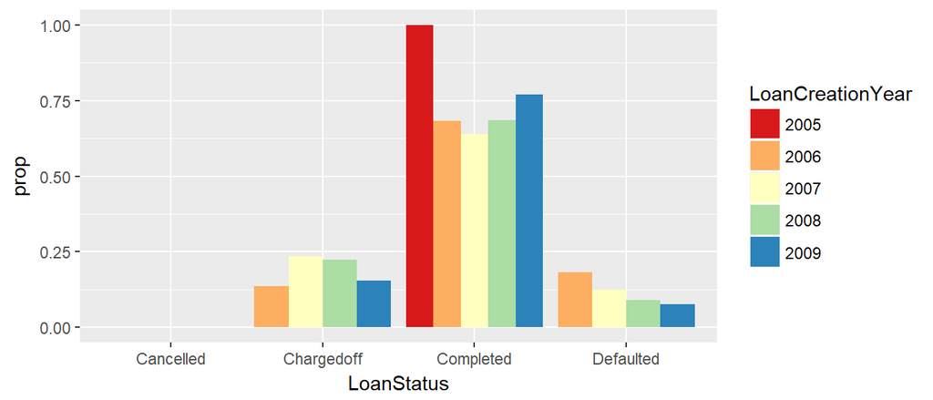

The bar chart now shows the correct proportions. For 2005, all loans are completed. For 2007, about 62.5% of loans were completed, 25% were charged off and about 12.5% defaulted as can be read off from the plot. Similar inferences can be drawn for the other years.

We also see the proportion of LoanStatuses as a Pie-Chart for all the years, prior to 2009. We will do the same including the years later than 2009 in a later section.

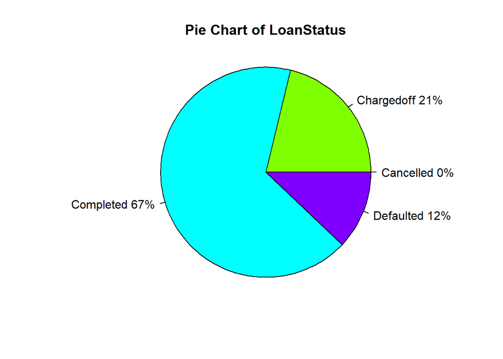

```r
"The proportions can be seen here :"
```

```
## [1] "The proportions can be seen here :"
```

```r
lbls
```

```
## [1] "Cancelled 0%"   "Chargedoff 21%" "Completed 67%"  "Defaulted 12%"
```

Now, lets do a bar chart and look at loanstatus for all data

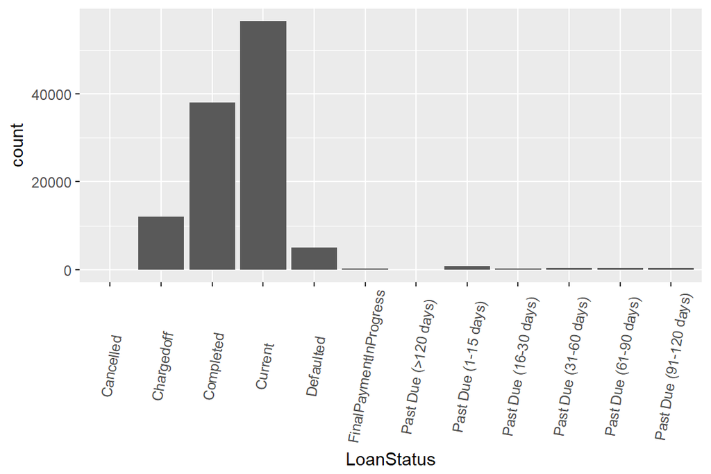

It looks like there are more categories of LoanStatuses for years after 2008. Lets look at the variable LoanCurrentDaysDelinquent and do it separately for the users with no allotted CreditGrade, and those who have a CreditGrade and view the LoanStatus Categories for the two datasets.

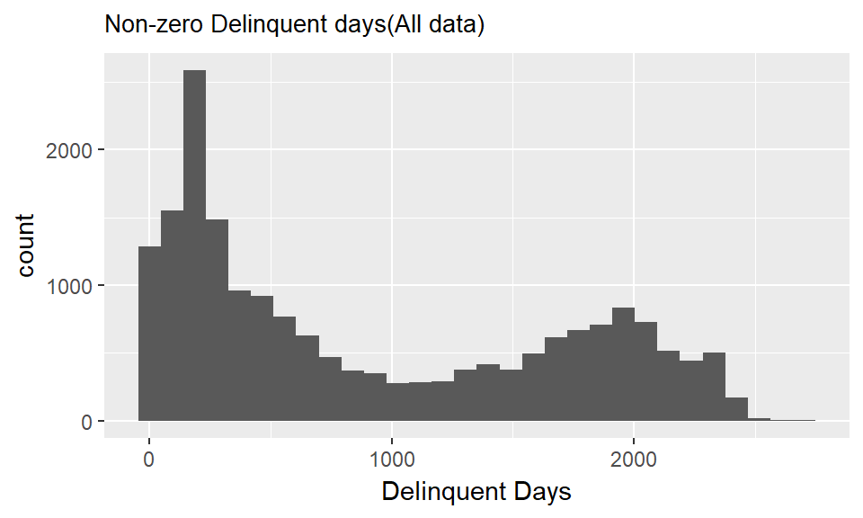

```
## [1] "Notice the two strange peaks. Lets look into this further"
```

```
## [1] "Plot Delinqent days for the entire dataset vs only those prior to 2008 and \nfacet it with LoanStatus"
```

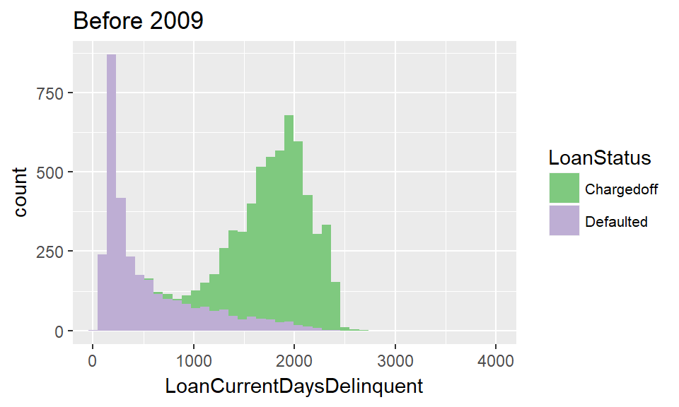

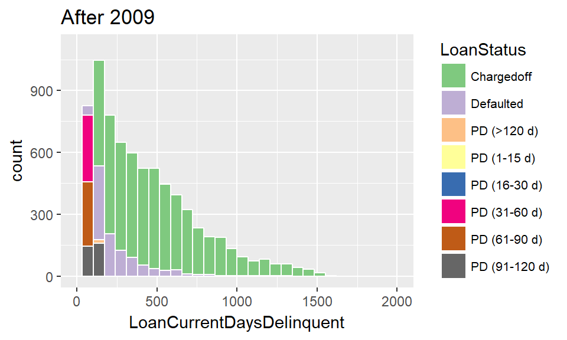

The plots above show how the LoanStatus relates to LoanCurrentDaysDelinquent. Since these two variables are closely related, I can use the LoanStatus from now on. Unexpectedly, the PastDues (1-15), and (16-30) dont seem to have any data, but a closer look shows the statistics is very low. See the plots below :

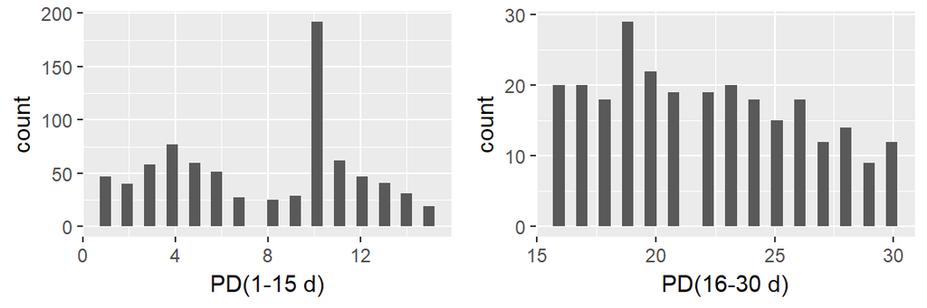

#### Transform the LoanStatus - Combine Past-Dues into Delinquent Category.

Since the past-dues are a very small fraction, lets combine them into a new “Delinquent” category and see the proportions in a pie-chart.

```
## [1] "Cancelled"              "Chargedoff"
## [3] "Completed"              "Current"
## [5] "Defaulted"              "FinalPaymentInProgress"
```

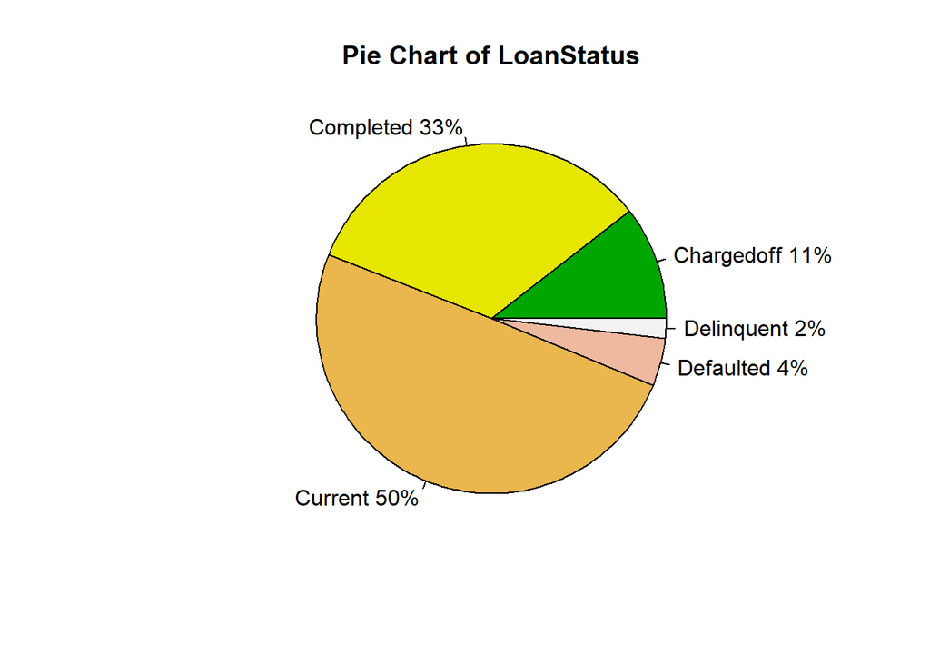

```r
"Pie chart proportions :"
```

```
## [1] "Pie chart proportions :"
```

```r
alllbls
```

```
## [1] "Cancelled"  "Chargedoff" "Completed"  "Current"    "Defaulted"
## [6] "FPI"        "Delinquent"
```

One can see that the “Cancelled”“,”FPI" are close to 0, so don’t appear in the pie chart as I removed them for the sake of clarity. Create a new Category NewLoanStatus and combine the “Pastdues”,“Cancelled” and “Defaulted” into “Delinquent” and others into “InGoodStanding”

```r
#make new values and put all the PastDue Accounts > 61 days as "Delinquent"
#and others in "Goodstanding" as below
df$NewLoanStatus <- as.character(df$LoanStatus)

dfs <- subset(df,!is.na(BorrowerAPR))

dfs$NewLoanStatus[(dfs$LoanStatus == "Cancelled" |
                  dfs$LoanStatus == "Defaulted" |
                  dfs$LoanStatus == "PD (31-60 d)" |
                  dfs$LoanStatus == "PD (61-90 d)" |
                  dfs$LoanStatus == "PD (91-120 d)" |
                  dfs$LoanStatus == "PD (>120 d)")] <- "Delinquent"

dfs$NewLoanStatus[(dfs$LoanStatus == "Current" |
                dfs$LoanStatus == "PD (1-15 d)" |
                dfs$LoanStatus == "PD (16-30 d)")] <- "InGoodStanding"

'Delinquent Loans are most likely to Default or have to be chargedoff.'
```

```
## [1] "Delinquent Loans are most likely to Default or have to be chargedoff."
```

```r
'Create a new dataframe dfs and transform the LoanStatus into these two new variables'
```

```
## [1] "Create a new dataframe dfs and transform the LoanStatus into these two new variables"
```

### Original Loan Amount and Loan Status

#### Does the OriginalLoanAmount have a bearing on the loanstatus?

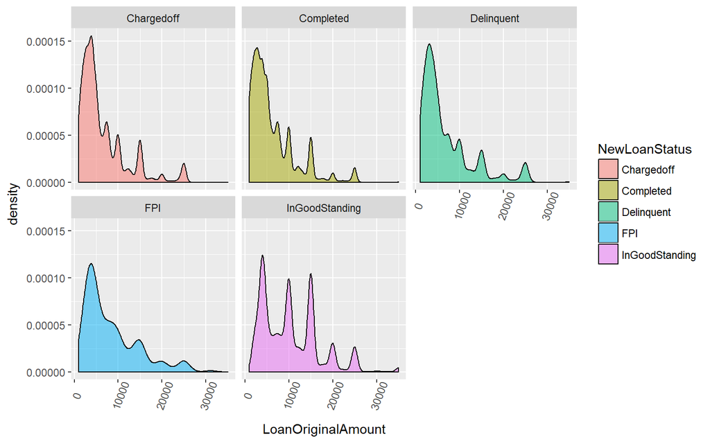

#### Do higher loan amounts have a higher probability of defaulting?

Most of the chargedoff loans lie below a certain amount, but that is true for other statuses as well.

From the densities, we might think that there is equal probability of a loan being charged off or completed regardless of the loan amount, as the shapes are very similar and the peaks are about the same height, however there are loans which are in progress which might get eventually paid off and also loans in good standing would probably get paid off as well. So, we can also combine these two categories into “GoodLoan” and the rest as a “BadLoan” and then compare again. I would have expected that higher loan amounts have a bigger chance of being defaulted in some way. Create another category and combine the “Chargedoff and Delinquent Loans” into a “Bad Loan” and others like “Current”,“Past Due (1-15 days)”,“Past Due (16-30 days)”, “FinalPaymentInProgress”,“Completed” into a “GoodLoan”

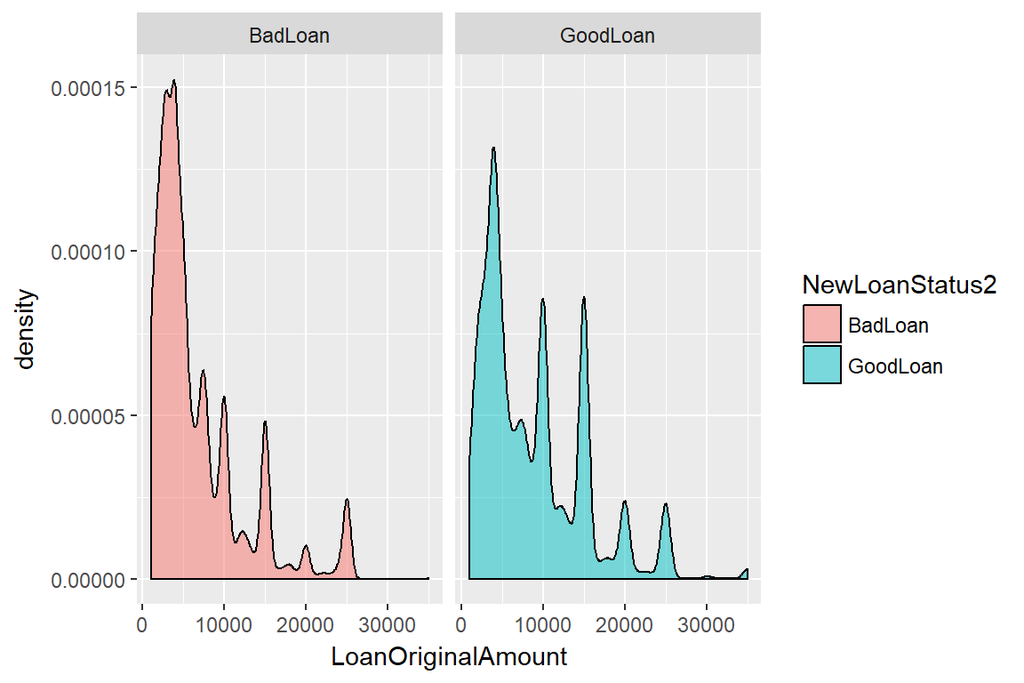

```r
cloangood <- c("InGoodStanding","Completed","FPI")

#Also combine the Charged off and Delinquent into "BadLoan"
cloanbad <- c("Chargedoff","Delinquent")
dfs$NewLoanStatus2[dfs$NewLoanStatus %in% cloangood] <- "GoodLoan"
dfs$NewLoanStatus2[dfs$NewLoanStatus %in% cloanbad] <- "BadLoan"
```

So, I made two categories of Loans : GoodLoans and BadLoans. The criteria can be seen as above.

Now, we see a different scenario! We see that Loan amounts of around 10000, 15000,20000 have a greater likelihood to be paid off. But unexpectedly for loans higher than 20000, it has a similar chance of being a Bad loan or a GoodLoan. Also, one can see that smaller loan amounts (<5000) have a higher likelihood of being bad loans and being defaulted in some way.

### How is the APR rate affected by the Credit Score?

I explore the relation between APR and CreditScore in the following:

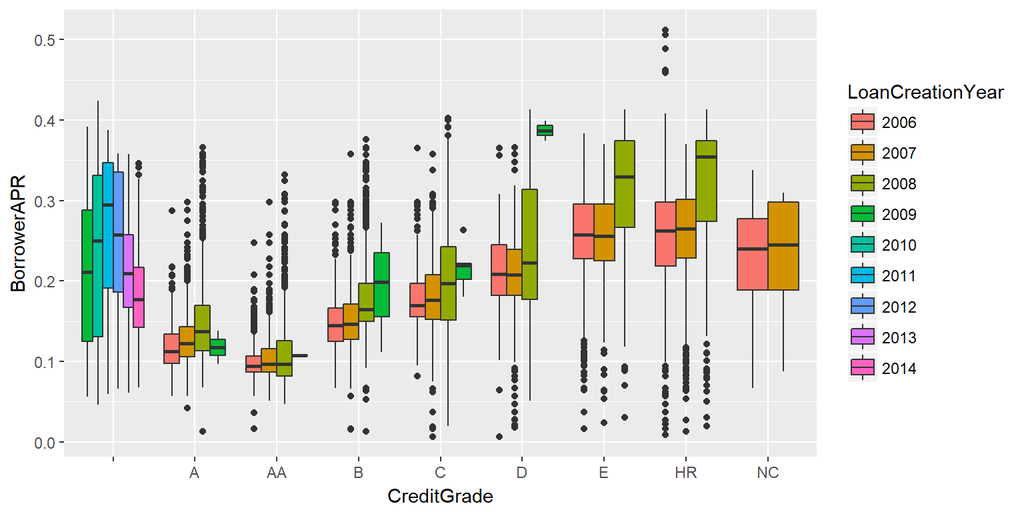

So I decided to investigate the relationship between CreditScore and CreditGrade

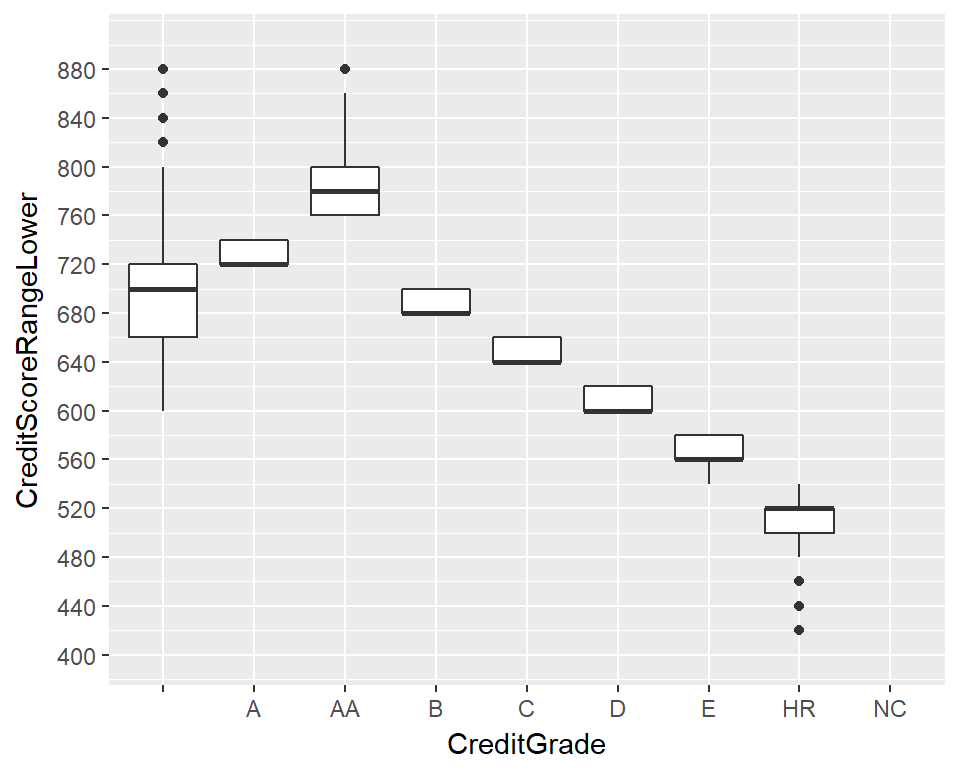

```r
ggplot(dfs,aes(y=CreditScoreRangeLower,x=CreditGrade))+geom_boxplot()+
  coord_cartesian(ylim=c(400,900))+
    scale_y_continuous(breaks=seq(400,900,40))
```

```r
#Lets get the maximum and minimum of each CreditGrade
dfcg_1 <- subset(dfs,!is.na(CreditScoreRangeLower))
grades <- sort(unique(dfcg_1$CreditGrade))
grades
```

```
## [1]    A  AA B  C  D  E  HR NC
## Levels:  A AA B C D E HR NC
```

```r
mins <- length(grades)
maxs <- length(grades)

for ( i in 1:length(grades)) {
  mins[i] <- min(dfcg_1$CreditScoreRangeLower[dfcg_1$CreditGrade==grades[i]])
  maxs[i] <- max(dfcg_1$CreditScoreRangeLower[dfcg_1$CreditGrade==grades[i]])
}
```

```
## [1] "These are the grades and their corresponding credit score ranges:"
```

```
##   grades mins maxs
## 1         600  880
## 2      A  720  740
## 3     AA  760  880
## 4      B  680  700
## 5      C  640  660
## 6      D  600  620
## 7      E  540  580
## 8     HR    0  540
## 9     NC    0    0
```

It looks like 104 users have a CreditGrade but don’t have a CreditScore. My NA count variable also shows that. So, most likely other factors were used for their CreditGrade. The first plot is used just to get an idea of how the range looks like and it is verified with the code.

The values for the creditscore range can be read off the boxplot but I also write a small code to show that it confirms the plot.

I use the above relation between CreditScore and Grade, and assign these Grades to the unknown Grades as well and create a “NewCreditGrade”. I understand that the grading methodology may differ for the next years, but in case it does not change this is a judicious choice to make. Now, we can look at how the Borrower APR and mean varies with the Credit Score.

```
## [1]    A  AA B  C  D  E  HR NC
## Levels:  A AA B C D E HR NC
```

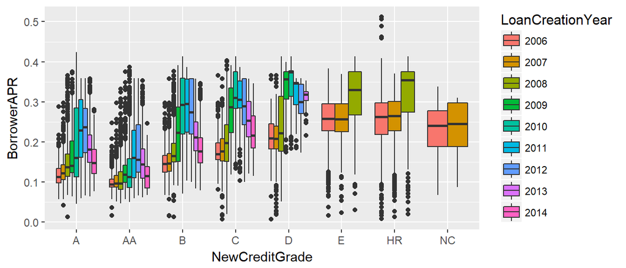

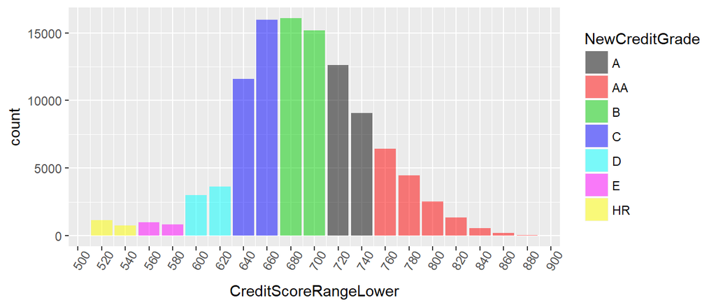

# BorrowerAPR vs CreditGrade

Now lets do the BorrowerAPR with the CreditGrade plot again.

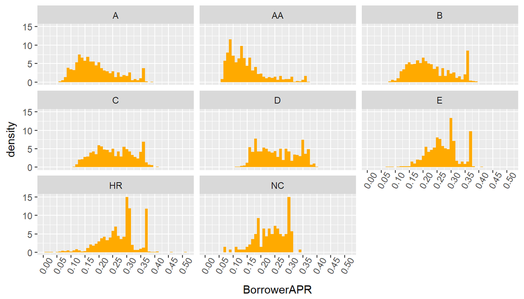

One can see that as the credit Grade goes lower, the borrowerAPR increases.

```
## [1] "Lets plot the Means and Standard Deviation vs Credit Grade"
```

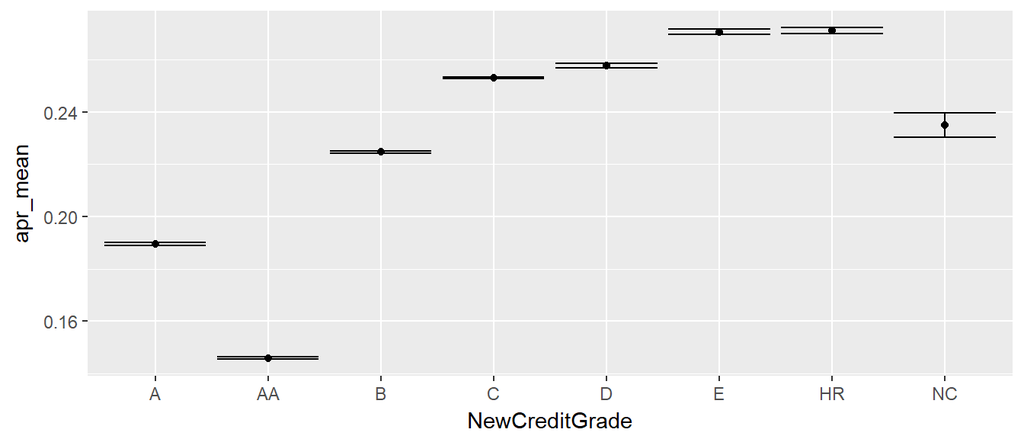

Here, we plot the mean APR and error on Mean vs CreditGrade and we can do a  
similar plot vs. CreditScore. Note that Grades AA - HR are in descending order of best to worst credit grades. So the trend is opposite in the two plots. The two plots below are similar but the top one shows the distribution of points with the mean superimposed, while the second one shows the mean with standard error for each bin, calculated as mean/sqrt(n-1) where n is the number of counts in each bin.

```
## [1] "BorrowerAPR vs CreditScoreRangeLower"
```

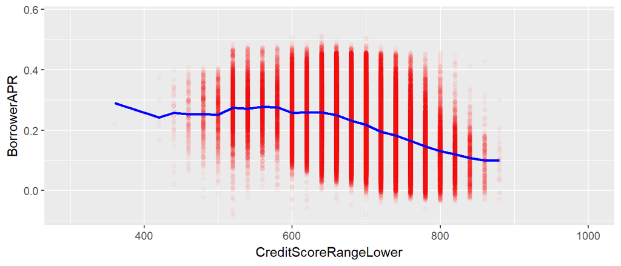

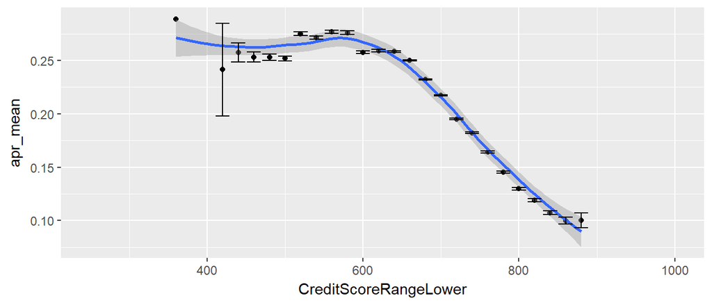

## Credit Score and factors which influence them.

I study here some variables which influence the CreditScore.Since there are a large number of variables, I first looked at their correlations, and study those which have a high correlation with the creditscore, which would imply that they influence the creditscore the most.

```
##                First.Variable          Second.Variable Correlation
## 23       CurrentDelinquencies          MeanCreditScore -0.36845005
## 22       InquiriesLast6Months          MeanCreditScore -0.26213513
## 24   PublicRecordsLast10Years          MeanCreditScore -0.21472582
## 18       CurrentDelinquencies PublicRecordsLast10Years  0.17964802
## 12       InquiriesLast6Months     CurrentDelinquencies  0.15634154
## 21 TotalCreditLinespast7years          MeanCreditScore  0.10870653
## 17       InquiriesLast6Months PublicRecordsLast10Years  0.08095925
## 6  TotalCreditLinespast7years     InquiriesLast6Months  0.07262889
## 11 TotalCreditLinespast7years     CurrentDelinquencies  0.06760066
## 16 TotalCreditLinespast7years PublicRecordsLast10Years  0.01266935
```

CurrentDelinquencies, InquiriesLast6Months,PublicRecordsLast10Years are the most correlated to the MeanCreditScore. Also, these three variables have a weak correlation with each other about 15-17%. Lets continue to study other variables. I study these variables separately based on their NA counts.

```
##              First.Variable        Second.Variable Correlation
## 84       CurrentCreditLines        OpenCreditLines   0.9603868
## 69              TotalTrades     CurrentCreditLines   0.6785642
## 82              TotalTrades        OpenCreditLines   0.6353523
## 159 AvailableBankcardCredit        MeanCreditScore   0.4537075
## 166     BankcardUtilization        MeanCreditScore  -0.4056417
## 120 AvailableBankcardCredit    BankcardUtilization  -0.3509937
## 111         OpenCreditLines RevolvingCreditBalance   0.3426509
## 110      CurrentCreditLines RevolvingCreditBalance   0.3335974
## 81  AvailableBankcardCredit        OpenCreditLines   0.3316802
## 68  AvailableBankcardCredit     CurrentCreditLines   0.3181076
```

So, I choose to study AvailableBankCardCredit, BankCardUtilization, CurrentCreditLines, and TotalTrades. What about RevolvingCreditBalance?

```
##                        RevolvingCreditBalance MeanCreditScore
## RevolvingCreditBalance             1.00000000      0.08884785
## MeanCreditScore                    0.08884785      1.00000000
```

```
##                   DebtToIncomeRatio MeanCreditScore
## DebtToIncomeRatio        1.00000000     -0.01316852
## MeanCreditScore         -0.01316852      1.00000000
```

I expected to see the DebtToIncomeRatio have a big impact on the CreditScore, but this shows a very weak Correlation. I find this unexpected. But I would like to still study it. And also, study the RevolvingCreditBalance. So finally, I choose the following variables to plot -

CurrentDelinquencies, InquiriesLast6Months, PublicRecordsLast10Years, AvailableBankCardCredit,  
BankCardUtilization, CurrentCreditLines, TotalTrades, DebtToIncomeRatio, RevolvingCreditBalance

I first plot the plots here and then discuss them below:

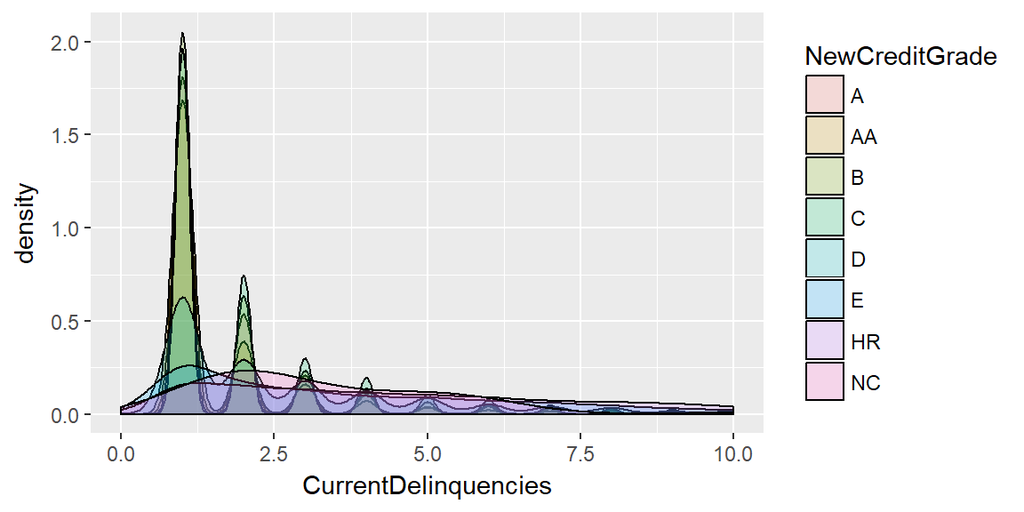

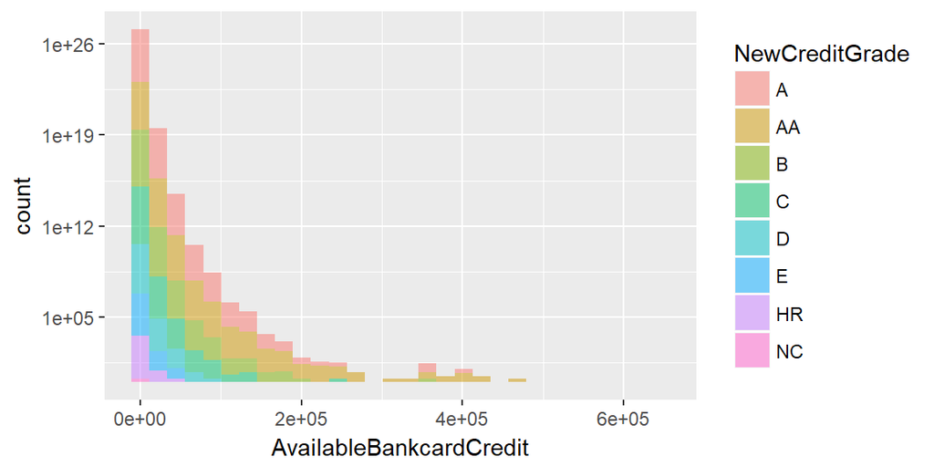

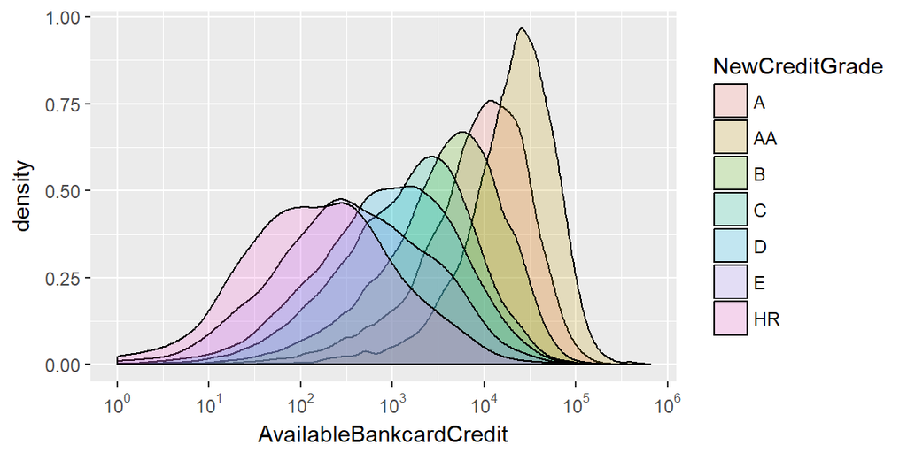

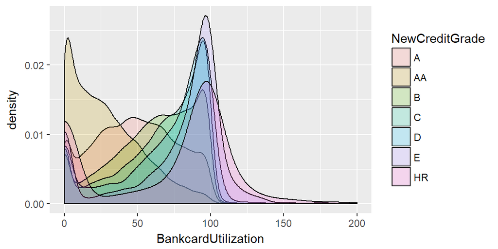